# TRABAJO DE APLICACION

John Michuy Galindo - Marcelo Pereyra Ruiz

2025-03-03

# BASE DE DATOS: COPA AMÉRICA 2024

Para el trabajo final, se utilizará un archivo llamado “Copa_America.csv” que contiene información detallada sobre los partidos de la Copa América 2024. Cada fila de este conjunto de datos representa un partido disputado en el torneo, y cada columna hace referencia a diferentes variables relacionadas con el encuentro, los equipos, el arbitraje y el rendimiento en el juego.

Las principales columnas del archivo son:

-ID_Partido: Identificador único de cada partido, tipo numeric

-Fecha: Fecha en la que se disputó el partido, tipo character

-Equipo_Local: Nombre del equipo local, tipo character

-Goles_Local: Goles anotados por el equipo local, tipo numeric

-Goles_Visitante: Goles anotados por el equipo visitante, tipo numeric

-Equipo_Visitante: Nombre del equipo visitante, tipo character

-Jornada: Semana del torneo en la que se jugó el partido, tipo numeric

-Fase_Torneo: Etapa del torneo, tipo character

-Estadio: Estadio donde se disputó el encuentro, tipo character

-Arbitro: Nombre del árbitro principal del partido, tipo character

-Pais_Arbitro: País de origen del árbitro, tipo character

-Entrenador_Local: Nombre del director técnico del equipo local, tipo character

-Pais_Entrenador_Local: País de origen del director técnico local, tipo character

-Entrenador_Visitante: Nombre del director técnico del equipo visitante, tipo character

-Pais_Entrenador_Visitante: País de origen del director técnico visitante, tipo character

-Asistencias_Disparos_Totales: Asistencias de tiro realizadas durante el partido, tipo numeric

-Disparos_Totales: Número total de disparos realizados, tipo numeric

-xG_Total: Goles esperados, tipo numeric

-Asistencias_Gol_Totales: Asistencias de gol concretadas, tipo numeric

-Goles_Totales: Goles anotados contando el de los penales, tipo numeric

-Autogoles: Goles en contra, tipo numeric

Este archivo tiene 32 registros, ya que son 32 partidos los que se disputaron en la Copa América 2024. Los primeros registros lucen así:

```r
library(tidyverse)
library(tibble)
library(scales)
```

```r
library(ggplot2)
datos <- read_delim("C:/Users/John/OneDrive/Documentos/UNMSM/25-0/PLE/PROYECTO/Copa_America.csv",delim=",")
datos
```

| ID_Partido | Fecha | Equipo_Local | Goles_Local | Goles_Visitante | Equipo_Visitante | Jornada | Fase_Torneo | Estadio | Arbitro | Pais_Arbitro | Entrenador_Local | Pais_Entrenador_Local | Entrenador_Visitante | Pais_Entrenador_Visitante | Asistencias_Disparos_Totales | Disparos_Totales | xG_Total | Asistencias_Gol_Totales | Goles_Totales | Autogoles |
| --- | --- | --- | --- | --- | --- | --- | --- | --- | --- | --- | --- | --- | --- | --- | --- | --- | --- | --- | --- | --- |
| 3943077 | 15/07/2024 | Argentina | 1 | 0 | Colombia | 6 | Final | Hard Rock Stadium | Raphael Claus | Brazil | Lionel Sebastián Scaloni | Argentina | Néstor Gabriel Lorenzo | Argentina | 25 | 30 | 2.070880 | 1 | 1 | 0 |
| 3943076 | 14/07/2024 | Canada | 2 | 2 | Uruguay | 6 | 3rd Place Final | Bank of America Stadium | Alexis Herrera | Venezuela (Bolivarian Republic) | Jesse Marsch | United States of America | Marcelo Alberto Bielsa Caldera | Argentina | 16 | 35 | 10.855736 | 1 | 11 | 0 |
| 3942852 | 11/07/2024 | Uruguay | 0 | 1 | Colombia | 5 | Semi-finals | Bank of America Stadium | César Arturo Ramos Palazuelos | Mexico | Marcelo Alberto Bielsa Caldera | Argentina | Néstor Gabriel Lorenzo | Argentina | 20 | 22 | 1.926524 | 1 | 1 | 0 |
| 3942785 | 10/07/2024 | Argentina | 2 | 0 | Canada | 5 | Semi-finals | MetLife Stadium | Piero Maza Gomez | Chile | Lionel Sebastián Scaloni | Argentina | Jesse Marsch | United States of America | 15 | 20 | 2.433422 | 1 | 2 | 0 |
| 3942416 | 07/07/2024 | Colombia | 5 | 0 | Panama | 4 | Quarter-finals | State Farm Stadium | Maurizio Mariani | Italy | Néstor Gabriel Lorenzo | Argentina | Thomas Christiansen Tarín | Spain | 9 | 21 | 2.790356 | 2 | 5 | 0 |
| 3942415 | 07/07/2024 | Uruguay | 0 | 0 | Brazil | 4 | Quarter-finals | Allegiant Stadium | Darío Herrera | Argentina | Marcelo Alberto Bielsa Caldera | Argentina | Dorival Silvestre Júnior | Brazil | 10 | 28 | 8.357211 | 0 | 6 | 0 |
| 3939986 | 30/06/2024 | Argentina | 2 | 0 | Peru | 3 | Group Stage | Hard Rock Stadium | César Arturo Ramos Palazuelos | Mexico | Lionel Sebastián Scaloni | Argentina | Jorge Daniel Fossati Lurachi | Uruguay | 10 | 19 | 2.272399 | 1 | 2 | 0 |
| 3939973 | 24/06/2024 | Uruguay | 3 | 1 | Panama | 1 | Group Stage | Hard Rock Stadium | Piero Maza Gomez | Chile | Marcelo Alberto Bielsa Caldera | Argentina | Thomas Christiansen Tarín | Spain | 19 | 30 | 1.902329 | 3 | 4 | 0 |
| 3942229 | 06/07/2024 | Venezuela | 1 | 1 | Canada | 4 | Quarter-finals | AT&T Stadium | Wilton Pereira Sampaio | Brazil | Fernando Ariel Batista | Argentina | Jesse Marsch | United States of America | 21 | 43 | 11.676652 | 1 | 9 | 0 |
| 3942228 | 05/07/2024 | Argentina | 1 | 1 | Ecuador | 4 | Quarter-finals | NRG Stadium | Andrés Matonte | Uruguay | Lionel Sebastián Scaloni | Argentina | Félix Sánchez Bas | Spain | 10 | 26 | 9.299265 | 2 | 8 | 0 |

[output cut: 22 more lines]

## **Estructura de datos**

```r
# Muestra la estructura interna del dataset
str(datos)
```

```
## spc_tbl_ [32 × 21] (S3: spec_tbl_df/tbl_df/tbl/data.frame)
##  $ ID_Partido                  : num [1:32] 3943077 3943076 3942852 3942785 3942416 ...
##  $ Fecha                       : chr [1:32] "15/07/2024" "14/07/2024" "11/07/2024" "10/07/2024" ...
##  $ Equipo_Local                : chr [1:32] "Argentina" "Canada" "Uruguay" "Argentina" ...
##  $ Goles_Local                 : num [1:32] 1 2 0 2 5 0 2 3 1 1 ...
##  $ Goles_Visitante             : num [1:32] 0 2 1 0 0 0 0 1 1 1 ...
##  $ Equipo_Visitante            : chr [1:32] "Colombia" "Uruguay" "Colombia" "Canada" ...
##  $ Jornada                     : num [1:32] 6 6 5 5 4 4 3 1 4 4 ...
##  $ Fase_Torneo                 : chr [1:32] "Final" "3rd Place Final" "Semi-finals" "Semi-finals" ...
##  $ Estadio                     : chr [1:32] "Hard Rock Stadium" "Bank of America Stadium" "Bank of America Stadium" "MetLife Stadium" ...
##  $ Arbitro                     : chr [1:32] "Raphael Claus" "Alexis Herrera" "César Arturo Ramos Palazuelos" "Piero Maza Gomez" ...
##  $ Pais_Arbitro                : chr [1:32] "Brazil" "Venezuela (Bolivarian Republic)" "Mexico" "Chile" ...
##  $ Entrenador_Local            : chr [1:32] "Lionel Sebastián Scaloni" "Jesse Marsch" "Marcelo Alberto Bielsa Caldera" "Lionel Sebastián Scaloni" ...
##  $ Pais_Entrenador_Local       : chr [1:32] "Argentina" "United States of America" "Argentina" "Argentina" ...
##  $ Entrenador_Visitante        : chr [1:32] "Néstor Gabriel Lorenzo" "Marcelo Alberto Bielsa Caldera" "Néstor Gabriel Lorenzo" "Jesse Marsch" ...
##  $ Pais_Entrenador_Visitante   : chr [1:32] "Argentina" "Argentina" "Argentina" "United States of America" ...
##  $ Asistencias_Disparos_Totales: num [1:32] 25 16 20 15 9 10 10 19 21 10 ...
##  $ Disparos_Totales            : num [1:32] 30 35 22 20 21 28 19 30 43 26 ...
##  $ xG_Total                    : num [1:32] 2.07 10.86 1.93 2.43 2.79 ...
##  $ Asistencias_Gol_Totales     : num [1:32] 1 1 1 1 2 0 1 3 1 2 ...
##  $ Goles_Totales               : num [1:32] 1 11 1 2 5 6 2 4 9 8 ...
##  $ Autogoles                   : num [1:32] 0 0 0 0 0 0 0 0 0 0 ...
##  - attr(*, "spec")=
##   .. cols(
##   ..   ID_Partido = col_double(),
##   ..   Fecha = col_character(),
##   ..   Equipo_Local = col_character(),
##   ..   Goles_Local = col_double(),
##   ..   Goles_Visitante = col_double(),
##   ..   Equipo_Visitante = col_character(),
##   ..   Jornada = col_double(),
##   ..   Fase_Torneo = col_character(),
##   ..   Estadio = col_character(),
##   ..   Arbitro = col_character(),
##   ..   Pais_Arbitro = col_character(),
##   ..   Entrenador_Local = col_character(),
##   ..   Pais_Entrenador_Local = col_character(),
##   ..   Entrenador_Visitante = col_character(),
##   ..   Pais_Entrenador_Visitante = col_character(),
##   ..   Asistencias_Disparos_Totales = col_double(),
##   ..   Disparos_Totales = col_double(),
##   ..   xG_Total = col_double(),
##   ..   Asistencias_Gol_Totales = col_double(),
##   ..   Goles_Totales = col_double(),
##   ..   Autogoles = col_double()
##   .. )
##  - attr(*, "problems")=<externalptr>
```

### **Creación y Renombre de variables**

Juntaremos las variables Equipo_Local y Equipo_Visitante, para saber que selecciones participaron en el partido.

```r
datos <- datos %>%
  mutate(Partido = paste(Equipo_Local, '-', Equipo_Visitante))
head(datos[c('Equipo_Local', 'Equipo_Visitante', 'Partido')], 32)
```

| Equipo_Local | Equipo_Visitante | Partido |
| --- | --- | --- |
| Argentina | Colombia | Argentina - Colombia |
| Canada | Uruguay | Canada - Uruguay |
| Uruguay | Colombia | Uruguay - Colombia |
| Argentina | Canada | Argentina - Canada |
| Colombia | Panama | Colombia - Panama |
| Uruguay | Brazil | Uruguay - Brazil |
| Argentina | Peru | Argentina - Peru |
| Uruguay | Panama | Uruguay - Panama |
| Venezuela | Canada | Venezuela - Canada |
| Argentina | Ecuador | Argentina - Ecuador |

[output cut: 22 more lines]

Vamos a calcular la cantitad total de goles que cada partido tuvo sin tomar en cuenta la tanda de penales (Goles_SinPenales), sumando la cantidad de goles anotados por el local con la cantidad de goles anotados por el visitante:

```r
datos <- mutate(datos, Goles_SinPenales = Goles_Local + Goles_Visitante)
head(datos[c('Partido', 'Goles_Local', 'Goles_Visitante', 'Goles_SinPenales')], 32)
```

| Partido | Goles_Local | Goles_Visitante | Goles_SinPenales |
| --- | --- | --- | --- |
| Argentina - Colombia | 1 | 0 | 1 |
| Canada - Uruguay | 2 | 2 | 4 |
| Uruguay - Colombia | 0 | 1 | 1 |
| Argentina - Canada | 2 | 0 | 2 |
| Colombia - Panama | 5 | 0 | 5 |
| Uruguay - Brazil | 0 | 0 | 0 |
| Argentina - Peru | 2 | 0 | 2 |
| Uruguay - Panama | 3 | 1 | 4 |
| Venezuela - Canada | 1 | 1 | 2 |
| Argentina - Ecuador | 1 | 1 | 2 |

[output cut: 22 more lines]

Crearemos una nueva columna que se llame Ganador y tenga el valor “Victorial Local” cuando Goles_Local > Goles_Visitante y “Victoria Visitante” en caso contrario. Si ocurre el caso de que Goles_Local = Goles_Visitante, se obtendrá el valor “Sin Ganador”

```r
datos <- mutate(datos, Ganador = case_when(
  Goles_Local > Goles_Visitante ~ 'Victoria Local',
  Goles_Local < Goles_Visitante ~ 'Victoria Visitante',
  TRUE ~ 'Sin Ganador'
))
head(datos[c('Partido', 'Goles_Local', 'Goles_Visitante', 'Ganador')], 32)
```

| Partido | Goles_Local | Goles_Visitante | Ganador |
| --- | --- | --- | --- |
| Argentina - Colombia | 1 | 0 | Victoria Local |
| Canada - Uruguay | 2 | 2 | Sin Ganador |
| Uruguay - Colombia | 0 | 1 | Victoria Visitante |
| Argentina - Canada | 2 | 0 | Victoria Local |
| Colombia - Panama | 5 | 0 | Victoria Local |
| Uruguay - Brazil | 0 | 0 | Sin Ganador |
| Argentina - Peru | 2 | 0 | Victoria Local |
| Uruguay - Panama | 3 | 1 | Victoria Local |
| Venezuela - Canada | 1 | 1 | Sin Ganador |
| Argentina - Ecuador | 1 | 1 | Sin Ganador |

[output cut: 22 more lines]

```r
datos <- datos %>%
  mutate(Efectividad = Goles_SinPenales / Disparos_Totales) %>%
  rename(Fecha_Partido = Fecha)

head(datos[c('Fecha_Partido', 'Partido', 'Goles_SinPenales', 'Disparos_Totales', 'Efectividad')], 32)
```

| Fecha_Partido | Partido | Goles_SinPenales | Disparos_Totales | Efectividad |
| --- | --- | --- | --- | --- |
| 15/07/2024 | Argentina - Colombia | 1 | 30 | 0.03333333 |
| 14/07/2024 | Canada - Uruguay | 4 | 35 | 0.11428571 |
| 11/07/2024 | Uruguay - Colombia | 1 | 22 | 0.04545455 |
| 10/07/2024 | Argentina - Canada | 2 | 20 | 0.10000000 |
| 07/07/2024 | Colombia - Panama | 5 | 21 | 0.23809524 |
| 07/07/2024 | Uruguay - Brazil | 0 | 28 | 0.00000000 |
| 30/06/2024 | Argentina - Peru | 2 | 19 | 0.10526316 |
| 24/06/2024 | Uruguay - Panama | 4 | 30 | 0.13333333 |
| 06/07/2024 | Venezuela - Canada | 2 | 43 | 0.04651163 |
| 05/07/2024 | Argentina - Ecuador | 2 | 26 | 0.07692308 |

[output cut: 22 more lines]

### **Recodificación de categorías**

Aquellos registros con “United States”, “Brazil”, “Canada”, “Peru”, “Mexico” y “Panama” en Equipo_Local y Equipo Visitante son reemplazados por “Estados Unidos”, “Brasil”, “Canadá”, “Perú”, “México” y “Panamá” respectivamente. Los otros valores quedan como estaban:

```r
datos <- datos %>%
  mutate(
    Equipo_Local = case_when(
      Equipo_Local == 'United States' ~ 'Estados Unidos',
      Equipo_Local == 'Brazil' ~ 'Brasil',
      Equipo_Local == 'Canada' ~ 'Canadá',
      Equipo_Local == 'Peru' ~ 'Perú',
      Equipo_Local == 'Mexico' ~ 'México',
      Equipo_Local == 'Panama' ~ 'Panamá',
      TRUE ~ Equipo_Local
    ),
    Equipo_Visitante = case_when(
      Equipo_Visitante == 'United States' ~ 'Estados Unidos',
      Equipo_Visitante == 'Brazil' ~ 'Brasil',
      Equipo_Visitante == 'Canada' ~ 'Canadá',
      Equipo_Visitante == 'Peru' ~ 'Perú',
      Equipo_Visitante == 'Mexico' ~ 'México',
      Equipo_Visitante == 'Panama' ~ 'Panamá',
      TRUE ~ Equipo_Visitante
    )
  )

head(datos[, c('Equipo_Local', 'Equipo_Visitante')], 32)
```

| Equipo_Local | Equipo_Visitante |
| --- | --- |
| Argentina | Colombia |
| Canadá | Uruguay |
| Uruguay | Colombia |
| Argentina | Canadá |
| Colombia | Panamá |
| Uruguay | Brasil |
| Argentina | Perú |
| Uruguay | Panamá |
| Venezuela | Canadá |
| Argentina | Ecuador |

[output cut: 22 more lines]

A continuación, los registros con “United States of America”, “Spain”, “Brazil”, “Mexico” y “Iceland” en Pais_Entrenador_Local y Pais_Entrenador_Visitante son reemplazados respectivamente por “Estados Unidos”, “España”, “Brasil”, “México” e “Islandia”.

```r
datos <- datos %>%
  mutate(
    Pais_Entrenador_Local = case_when(
      Pais_Entrenador_Local == 'United States of America' ~ 'Estados Unidos',
      Pais_Entrenador_Local == 'Spain' ~ 'España',
      Pais_Entrenador_Local == 'Brazil' ~ 'Brasil',
      Pais_Entrenador_Local == 'Mexico' ~ 'México',
      Pais_Entrenador_Local == 'Iceland' ~ 'Islandia',
      TRUE ~Pais_Entrenador_Local
    ),
    Pais_Entrenador_Visitante = case_when(
      Pais_Entrenador_Visitante == 'United States of America' ~ 'Estados Unidos',
      Pais_Entrenador_Visitante == 'Spain' ~ 'España',
      Pais_Entrenador_Visitante == 'Brazil' ~ 'Brasil',
      Pais_Entrenador_Visitante == 'Mexico' ~ 'México',
      Pais_Entrenador_Visitante == 'Iceland' ~ 'Islandia',
      TRUE ~ Pais_Entrenador_Visitante
    )
  )

head(datos[, c('Equipo_Local', 'Pais_Entrenador_Local', 'Equipo_Visitante', 'Pais_Entrenador_Visitante')], 32)
```

| Equipo_Local | Pais_Entrenador_Local | Equipo_Visitante | Pais_Entrenador_Visitante |
| --- | --- | --- | --- |
| Argentina | Argentina | Colombia | Argentina |
| Canadá | Estados Unidos | Uruguay | Argentina |
| Uruguay | Argentina | Colombia | Argentina |
| Argentina | Argentina | Canadá | Estados Unidos |
| Colombia | Argentina | Panamá | España |
| Uruguay | Argentina | Brasil | Brasil |
| Argentina | Argentina | Perú | Uruguay |
| Uruguay | Argentina | Panamá | España |
| Venezuela | Argentina | Canadá | Estados Unidos |
| Argentina | Argentina | Ecuador | España |

[output cut: 22 more lines]

Finalmente, cambiaremos los registros de Pais_Arbitro donde “United States of America”, “Venezuela (Bolivarian Republic)”, “Brazil”, “Mexico”, “Italy” y “Peru” se volverán “Estados Unidos”, “Venezuela”, “Brasil”, “México”, “Italia” y “Perú” de manera respectiva.

```r
datos <- mutate(datos,
    Pais_Arbitro = case_when(
      Pais_Arbitro == 'United States of America' ~ 'Estados Unidos',
      str_detect(Pais_Arbitro, "Venezuela") ~ 'Venezuela',
      Pais_Arbitro == 'Brazil' ~ 'Brasil',
      Pais_Arbitro == 'Mexico' ~ 'México',
      Pais_Arbitro == 'Italy' ~ 'Italia',
      Pais_Arbitro == 'Peru' ~ 'Perú',
      TRUE ~ Pais_Arbitro
      )
    )

head(datos[, c('Arbitro', 'Pais_Arbitro')], 32)
```

| Arbitro | Pais_Arbitro |
| --- | --- |
| Raphael Claus | Brasil |
| Alexis Herrera | Venezuela |
| César Arturo Ramos Palazuelos | México |
| Piero Maza Gomez | Chile |
| Maurizio Mariani | Italia |
| Darío Herrera | Argentina |
| César Arturo Ramos Palazuelos | México |
| Piero Maza Gomez | Chile |
| Wilton Pereira Sampaio | Brasil |
| Andrés Matonte | Uruguay |

[output cut: 22 more lines]

# ORGANIZACIÓN DE DATOS: Tablas de frecuencias y Gráficos Estadísticos

## **Tablas de frecuencias y Gráficos Estadísticos para variables cualitativas**

**Tabla de frecuencias**

```r
frecuencias <- datos %>%
  group_by(Estadio) %>%
  summarise(Frecuencia = n()) %>%
  mutate(Frecuencia_Relativa = Frecuencia / sum(Frecuencia),
         Frecuencia_Porcentual = Frecuencia_Relativa * 100)

frecuencias
```

| Estadio | Frecuencia | Frecuencia_Relativa | Frecuencia_Porcentual |
| --- | --- | --- | --- |
| AT&T Stadium | 3 | 0.09375 | 9.375 |
| Allegiant Stadium | 3 | 0.09375 | 9.375 |
| Arrowhead Stadium | 1 | 0.03125 | 3.125 |
| Bank of America Stadium | 2 | 0.06250 | 6.250 |
| Children''s Mercy Park | 1 | 0.03125 | 3.125 |
| Hard Rock Stadium | 3 | 0.09375 | 9.375 |
| Inter&Co Stadium | 1 | 0.03125 | 3.125 |
| Levi''s Stadium | 2 | 0.06250 | 6.250 |
| Mercedes-Benz Stadium | 2 | 0.06250 | 6.250 |
| MetLife Stadium | 3 | 0.09375 | 9.375 |

[output cut: 5 more lines]

**Gráficos de Barras y Sector Circular**

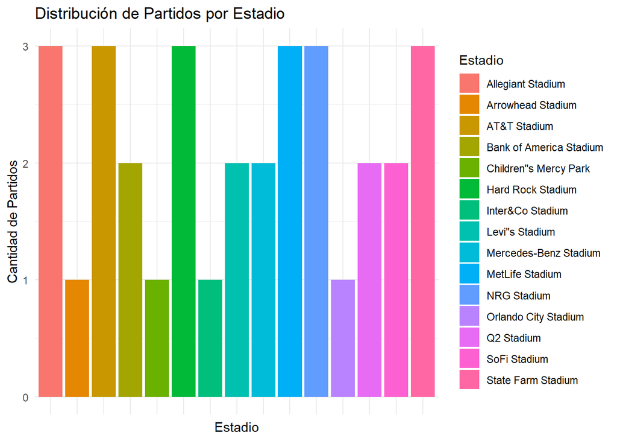

```r
# **Gráfico de barras**
grafico_barras <- ggplot(frecuencias, aes(x = Estadio, y = Frecuencia, fill = Estadio)) +
  geom_bar(stat = "identity") +
  theme_minimal() +
  labs(title = "Distribución de Partidos por Estadio", x = "Estadio", y = "Cantidad de Partidos") +
  theme(
    axis.text.x = element_blank(),
    axis.ticks.x = element_blank()
  )

print(grafico_barras)
```

# **Gráfico de sectores (pastel)**

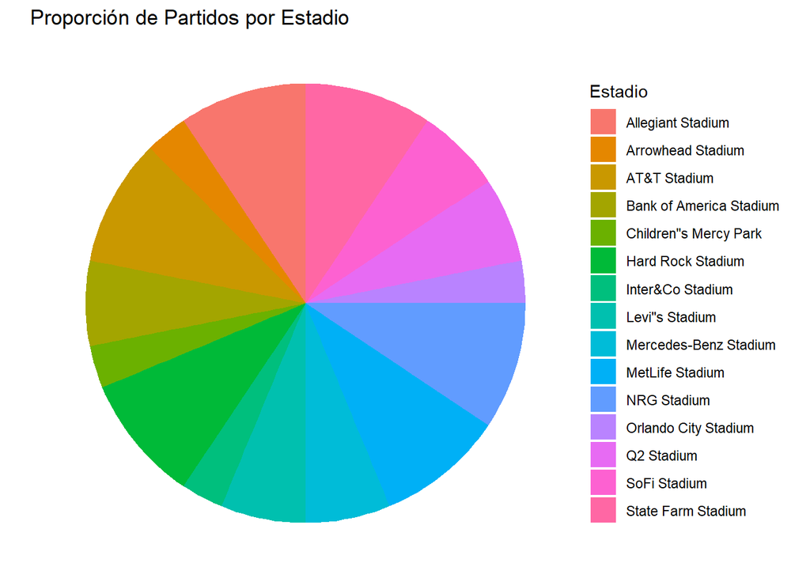

```r
grafico_pie <- ggplot(frecuencias, aes(x = "", y = Frecuencia, fill = Estadio)) +
  geom_bar(stat = "identity", width = 1) +
  coord_polar(theta = "y") +
  theme_void() +
  labs(title = "Proporción de Partidos por Estadio")

print(grafico_pie)
```

## **Tablas de frecuencias y Gráficos Estadísticos para variable cuantitativa discreta**

**Tabla de frecuencias**

```r
frecuencias <- datos %>%
  group_by(Goles_SinPenales) %>%
  summarise(Frecuencia = n()) %>%
  mutate(Frecuencia_Relativa = Frecuencia / sum(Frecuencia),
         Frecuencia_Porcentual = Frecuencia_Relativa * 100) %>%
  arrange(desc(Frecuencia)) %>%  # Ordenar de mayor a menor frecuencia
  mutate(Frecuencia_Acumulada = cumsum(Frecuencia),
         Frecuencia_Relativa_Acumulada = cumsum(Frecuencia_Relativa),
         Frecuencia_Porcentual_Acumulada = cumsum(Frecuencia_Porcentual))

print(frecuencias)
```

```
## # A tibble: 6 × 7
##   Goles_SinPenales Frecuencia Frecuencia_Relativa Frecuencia_Porcentual
##              <dbl>      <int>               <dbl>                 <dbl>
## 1                1          7              0.219                  21.9
## 2                2          7              0.219                  21.9
## 3                3          6              0.188                  18.8
## 4                0          5              0.156                  15.6
## 5                4          4              0.125                  12.5
## 6                5          3              0.0938                  9.38
## # ℹ 3 more variables: Frecuencia_Acumulada <int>,
## #   Frecuencia_Relativa_Acumulada <dbl>, Frecuencia_Porcentual_Acumulada <dbl>
```

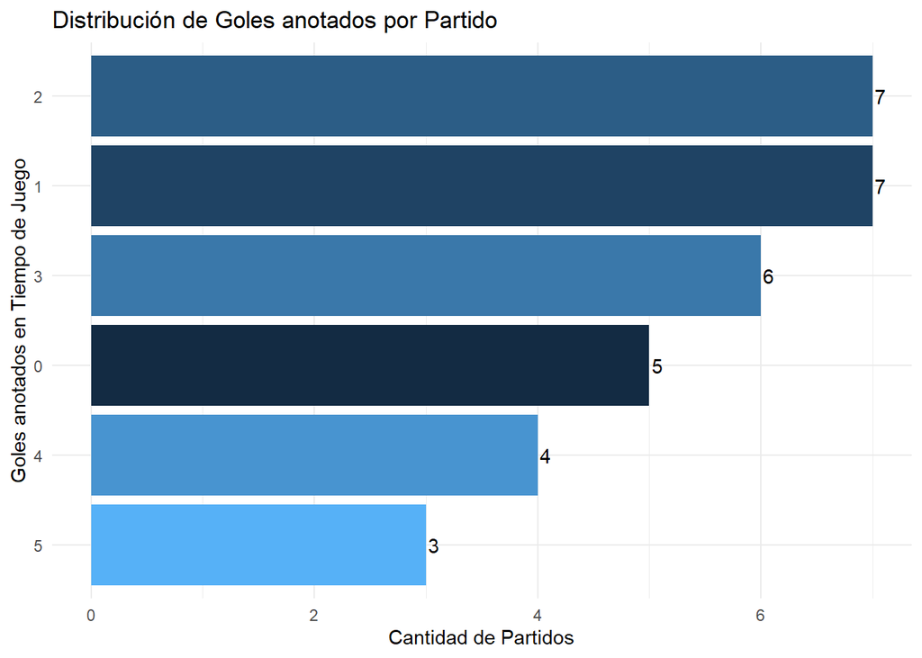

```r
ggplot(frecuencias, aes(x = reorder(Goles_SinPenales, Frecuencia), y = Frecuencia, fill = Goles_SinPenales)) +
  geom_col() +
  coord_flip() +
  labs(title = "Distribución de Goles anotados por Partido",
       x = "Goles anotados en Tiempo de Juego",
       y = "Cantidad de Partidos") +
  theme_minimal() +
  theme(legend.position = "none") +
  geom_text(aes(label = Frecuencia), hjust = -0.2, color = "black")
```

## **Tablas de frecuencias y Gráficos Estadísticos para variable cuantitativa continua**

**Cálculo del rango, número de intervalos y amplitud**

```r
rango <- max(datos$xG_Total)-min(datos$xG_Total)
k <- round(1 + 3.3*log10(32),0)
A <- ceiling(rango/k)
cbind(rango,k,A)
```

```
##         rango k A
## [1,] 10.52315 6 2
```

Creación de la variable xG Total por intervalos (k = 6 intervalos) con una amplitud igual a 2, la cual se llamará xG_intervalos

```r
datos <- mutate(datos, xG_intervalos = cut(xG_Total, breaks = seq(min(datos$xG_Total), max(datos$xG_Total) + A, A), right = FALSE))
head(datos)
```

| ID_Partido | Fecha_Partido | Equipo_Local | Goles_Local | Goles_Visitante | Equipo_Visitante | Jornada | Fase_Torneo | Estadio | Arbitro | Pais_Arbitro | Entrenador_Local | Pais_Entrenador_Local | Entrenador_Visitante | Pais_Entrenador_Visitante | Asistencias_Disparos_Totales | Disparos_Totales | xG_Total | Asistencias_Gol_Totales | Goles_Totales | Autogoles | Partido | Goles_SinPenales | Ganador | Efectividad | xG_intervalos |
| --- | --- | --- | --- | --- | --- | --- | --- | --- | --- | --- | --- | --- | --- | --- | --- | --- | --- | --- | --- | --- | --- | --- | --- | --- | --- |
| 3943077 | 15/07/2024 | Argentina | 1 | 0 | Colombia | 6 | Final | Hard Rock Stadium | Raphael Claus | Brasil | Lionel Sebastián Scaloni | Argentina | Néstor Gabriel Lorenzo | Argentina | 25 | 30 | 2.070880 | 1 | 1 | 0 | Argentina - Colombia | 1 | Victoria Local | 0.03333333 | [1.15,3.15) |
| 3943076 | 14/07/2024 | Canadá | 2 | 2 | Uruguay | 6 | 3rd Place Final | Bank of America Stadium | Alexis Herrera | Venezuela | Jesse Marsch | Estados Unidos | Marcelo Alberto Bielsa Caldera | Argentina | 16 | 35 | 10.855736 | 1 | 11 | 0 | Canada - Uruguay | 4 | Sin Ganador | 0.11428571 | [9.15,11.2) |
| 3942852 | 11/07/2024 | Uruguay | 0 | 1 | Colombia | 5 | Semi-finals | Bank of America Stadium | César Arturo Ramos Palazuelos | México | Marcelo Alberto Bielsa Caldera | Argentina | Néstor Gabriel Lorenzo | Argentina | 20 | 22 | 1.926524 | 1 | 1 | 0 | Uruguay - Colombia | 1 | Victoria Visitante | 0.04545455 | [1.15,3.15) |
| 3942785 | 10/07/2024 | Argentina | 2 | 0 | Canadá | 5 | Semi-finals | MetLife Stadium | Piero Maza Gomez | Chile | Lionel Sebastián Scaloni | Argentina | Jesse Marsch | Estados Unidos | 15 | 20 | 2.433422 | 1 | 2 | 0 | Argentina - Canada | 2 | Victoria Local | 0.10000000 | [1.15,3.15) |
| 3942416 | 07/07/2024 | Colombia | 5 | 0 | Panamá | 4 | Quarter-finals | State Farm Stadium | Maurizio Mariani | Italia | Néstor Gabriel Lorenzo | Argentina | Thomas Christiansen Tarín | España | 9 | 21 | 2.790356 | 2 | 5 | 0 | Colombia - Panama | 5 | Victoria Local | 0.23809524 | [1.15,3.15) |
| 3942415 | 07/07/2024 | Uruguay | 0 | 0 | Brasil | 4 | Quarter-finals | Allegiant Stadium | Darío Herrera | Argentina | Marcelo Alberto Bielsa Caldera | Argentina | Dorival Silvestre Júnior | Brasil | 10 | 28 | 8.357211 | 0 | 6 | 0 | Uruguay - Brazil | 0 | Sin Ganador | 0.00000000 | [7.15,9.15) |

# **Tabla de frecuencias**

```r
frecuencias <- datos %>%
  group_by(xG_intervalos) %>%
  summarise(Frecuencia = n()) %>%
  mutate(Frecuencia_Relativa = Frecuencia / sum(Frecuencia),
         Frecuencia_Porcentual = Frecuencia_Relativa * 100,
         Frecuencia_Relativa_Acumulada = cumsum(Frecuencia_Relativa),
         Frecuencia_Porcentual_Acumulada = cumsum(Frecuencia_Porcentual))

frecuencias
```

| xG_intervalos | Frecuencia | Frecuencia_Relativa | Frecuencia_Porcentual | Frecuencia_Relativa_Acumulada | Frecuencia_Porcentual_Acumulada |
| --- | --- | --- | --- | --- | --- |
| [1.15,3.15) | 24 | 0.75000 | 75.000 | 0.75000 | 75.000 |
| [3.15,5.15) | 4 | 0.12500 | 12.500 | 0.87500 | 87.500 |
| [7.15,9.15) | 1 | 0.03125 | 3.125 | 0.90625 | 90.625 |
| [9.15,11.2) | 2 | 0.06250 | 6.250 | 0.96875 | 96.875 |
| [11.2,13.2) | 1 | 0.03125 | 3.125 | 1.00000 | 100.000 |

**Histograma**

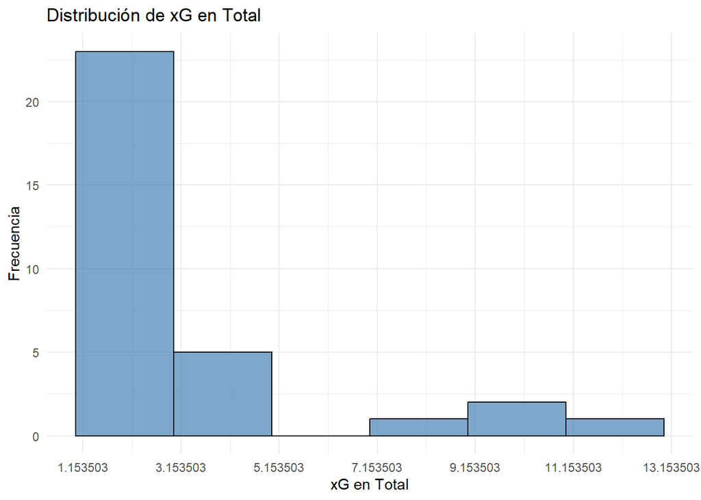

```r
histograma_xG <- ggplot(datos, aes(x = xG_Total)) +
  geom_histogram(binwidth = A, fill = "steelblue", color = "black", alpha = 0.7) +
  theme_minimal() +
  scale_x_continuous(breaks = seq(min(datos$xG_Total), max(datos$xG_Total) + A, A)) +
  labs(title = "Distribución de xG en Total", x = "xG en Total", y = "Frecuencia")

# Mostrar histograma
print(histograma_xG)
```

### **Tabla de Contingencia**

```r
##Distribución conjunta de las variables

library(janitor)
tabla_contingencia <- datos %>%
  tabyl(Goles_SinPenales, Fase_Torneo) %>%
  adorn_totals(where = c("row", "col")) %>%
  adorn_percentages(denominator = "all") %>%
  adorn_pct_formatting(digits = 1) %>%
  adorn_ns() %>%
  adorn_title(placement = "top", "Fase del Torneo", "Goles Sin Penales")

tabla_contingencia
```

|  | Goles Sin Penales |  |  |  |  |  |
| --- | --- | --- | --- | --- | --- | --- |
| Fase del Torneo | 3rd Place Final | Final | Group Stage | Quarter-finals | Semi-finals | Total |
| 0 | 0.0% (0) | 0.0% (0) | 12.5% (4) | 3.1% (1) | 0.0% (0) | 15.6% (5) |
| 1 | 0.0% (0) | 3.1% (1) | 15.6% (5) | 0.0% (0) | 3.1% (1) | 21.9% (7) |
| 2 | 0.0% (0) | 0.0% (0) | 12.5% (4) | 6.2% (2) | 3.1% (1) | 21.9% (7) |
| 3 | 0.0% (0) | 0.0% (0) | 18.8% (6) | 0.0% (0) | 0.0% (0) | 18.8% (6) |
| 4 | 3.1% (1) | 0.0% (0) | 9.4% (3) | 0.0% (0) | 0.0% (0) | 12.5% (4) |
| 5 | 0.0% (0) | 0.0% (0) | 6.2% (2) | 3.1% (1) | 0.0% (0) | 9.4% (3) |
| Total | 3.1% (1) | 3.1% (1) | 75.0% (24) | 12.5% (4) | 6.2% (2) | 100.0% (32) |

# **MEDIDAS DE TENDENCIA CENTRAL, DISPERSIÓN, POSICIÓN, ASIMETRÍA Y CURTOSIS**

## **Medidas de resumen para una variable cuantitativa**

### Tendencia central: media, mediana, moda.

Este fragmento calcula las **medidas de tendencia central** de los goles totales, generados en cada partido de la copa america, considerando los goles producidos en los 90 minutos, tiempo extras y penales. Con la variable `Goles_Totales` en el dataset `datos`, se uso la función `summarise()` de `dplyr`, para resumir los datos.

```r
library(dplyr)
library(DescTools)

TCentral <- datos %>%
  summarise(media = mean(Goles_Totales),
            mediana = median(Goles_Totales),
            Moda1 = Mode(Goles_Totales)[1],
            Moda2 = Mode(Goles_Totales)[2],
            )

TCentral
```

| media | mediana | Moda1 | Moda2 |
| --- | --- | --- | --- |
| 2.96875 | 2.5 | 1 | 3 |

### Dispersión: varianza, desviación estándar, coeficiente de variación.

Este código calcula las **medidas de dispersión** de la variable `Asistencias_Disparos_Totales` en el dataset `datos`, utilizando `summarise()` de `dplyr`. Obtiene la **media, mínimo, máximo, rango, varianza, desviación estándar y coeficiente de variación**, lo que permite analizar la variabilidad de los datos.

```r
Dispersion <- datos %>%
  summarise(
    media = mean(Asistencias_Disparos_Totales),              # media aritmética
    minimo = min(Asistencias_Disparos_Totales),              # valor mínimo
    maximo = max(Asistencias_Disparos_Totales),              # valor máximo
    rango = maximo - minimo,                  # rango
    Varianza = var(Asistencias_Disparos_Totales),            # varianza
    Desviacion = sd(Asistencias_Disparos_Totales),           # desviacion_estandar
    Coef_Variacion = (sd(Asistencias_Disparos_Totales) / media) * 100 # coeficiente de variacion
  )

Dispersion
```

| media | minimo | maximo | rango | Varianza | Desviacion | Coef_Variacion |
| --- | --- | --- | --- | --- | --- | --- |
| 14.65625 | 7 | 25 | 18 | 19.00706 | 4.359708 | 29.74641 |

### Asimetría y curtosis: interpretación de la forma de distribución.

Este código evalúa la asimetría y curtosis de los goles totales en los partidos de la Copa América, ayudando a comprender la forma de su distribución.

Asimetría (skewness()): Permite identificar si los partidos con muchos goles son atípicos o si los datos están equilibrados en torno a la media.

Curtosis (kurtosis()): Indica si hay una alta concentración de partidos con un número de goles cercano a la media o si existen valores extremos (goleadas inusuales).

Esta información es clave para entender la tendencia de los marcadores y su variabilidad en el torneo.

```r
library(dplyr)
library(moments)  # Para skewness() y kurtosis()

Asimetria_Curtosis <- datos %>%
  summarise(
    Asimetria_Goles = skewness(Goles_Totales),
    Curtosis_Goles = kurtosis(Goles_Totales),
    n = n()
  )
Asimetria_Curtosis
```

| Asimetria_Goles | Curtosis_Goles | n |
| --- | --- | --- |
| 1.340513 | 4.542426 | 32 |

### Calcular cuartiles y percentiles

Este código calcula los **cuartiles y percentiles** de los goles totales en los de la Copa América, usando `quantile()` dentro de `summarise()`.

- **Cuartiles (Q1, Q2, Q3)**: Dividen los datos en cuatro partes, mostrando la dispersión de los goles.
- **Percentiles (P10, P35, P68, P90)**: Ayudan a identificar puntos de referencia en la distribución, útil para analizar tendencias y valores atípicos.

Estos valores permiten interpretar la distribución de los goles y entender qué tan comunes son ciertos rangos de anotaciones en el torneo.

```r
library(dplyr)

Cuartiles_Percentiles <- datos %>%
  summarise(
    Q1 = quantile(Goles_Totales, 0.25),  # Primer cuartil (25%)
    Q2 = quantile(Goles_Totales, 0.50),  # Segundo cuartil (Mediana, 50%)
    Q3 = quantile(Goles_Totales, 0.75),  # Tercer cuartil (75%)
    P10 = quantile(Goles_Totales, 0.10), # Percentil 10
    P35 = quantile(Goles_Totales, 0.35),  # Percentil 35
    P68 = quantile(Goles_Totales, 0.68),  # Percentil 68
    P90 = quantile(Goles_Totales, 0.90)  # Percentil 90
  )
Cuartiles_Percentiles
```

| Q1 | Q2 | Q3 | P10 | P35 | P68 | P90 |
| --- | --- | --- | --- | --- | --- | --- |
| 1 | 2.5 | 4 | 0.1 | 1.85 | 3 | 5.9 |

## **Medidas de resumen de una variable cuantitativa agrupada por una cualitativa**

- **Agrupación por `Fase_Torneo`**: Permite analizar cómo varían los valores según la etapa del torneo.
- **Media, mediana y moda**: Ayudan a entender la distribución del `xG_Total` en cada fase.

**Ejemplo:** Si la media de `xG_Total` en la fase de grupos es mayor que en las eliminatorias, podría indicar que en la primera etapa se generan más oportunidades de gol.

```r
# Calcular medidas de tendencia central para una variable ("puntos")
medidas <- datos %>%
  group_by(Fase_Torneo) %>%
  summarise(
    media = mean(xG_Total),                   # Media aritmética
    mediana = median(xG_Total),               # Mediana
    moda = as.numeric(names(sort(table(xG_Total), decreasing = TRUE)[1])),  # Moda
  )
```

```r
data <- datos %>%
  group_by(Fase_Torneo)%>%
  select(Jornada, Equipo_Local, Goles_Local,    Goles_Visitante,    Equipo_Visitante)%>%
  arrange(desc(Jornada))
```

### Asimetría y curtosis por `Disparos_Totales`

Este código calcula **asimetría y curtosis** de los `Disparos_Totales`, agrupados por `Jornada`, usando `group_by()` y `summarise()`.

- **Asimetría (`skewness()`)**: Indica si la distribución de disparos por jornada está sesgada.
- **Curtosis (`kurtosis()`)**: Mide si los disparos están concentrados alrededor de la media o si hay valores extremos.
- **`n`**: Cantidad de registros por jornada.

**Ejemplo:** Si una jornada tiene alta curtosis, significa que hubo partidos con muchos disparos atípicos, como encuentros muy ofensivos o dominados por un solo equipo.

```r
datos %>%
  group_by(Jornada) %>%
  summarise(
    asimetria = skewness(Disparos_Totales),      # Coeficiente de asimetría
    curtosis = kurtosis(Disparos_Totales),       # Curtosis
    n = n()                                      # Número de registros
  )
```

| Jornada | asimetria | curtosis | n |
| --- | --- | --- | --- |
| 1 | 0.1197122 | 1.877762 | 8 |
| 2 | -0.3161639 | 2.163792 | 8 |
| 3 | 1.1594155 | 3.086271 | 8 |
| 4 | 0.8159698 | 2.133207 | 4 |
| 5 | 0.0000000 | 1.000000 | 2 |
| 6 | 0.0000000 | 1.000000 | 2 |

### Cuartiles y percentiles por `Asistencias_Disparos_Totales`

Este código calcula **cuartiles y percentiles** de `Asistencias_Disparos_Totales`, agrupados por `Estadio`, utilizando `group_by()` y `summarise()`.

- **Cuartiles (Q1, Q2, Q3)**: Muestran la distribución de los valores en cada estadio.
- **Percentiles (P10, P35, P68, P90)**: Identifican puntos clave en la dispersión de los datos.

**Ejemplo:** Si en un estadio el `P90` es alto, indica que en el 10% de los partidos ahí disputados hubo muchas asistencias de disparo, lo que podría sugerir que el campo o las condiciones favorecen el juego ofensivo.

```r
library(dplyr)

datos %>%
  group_by(Estadio) %>%
  summarise(
    Q1 = quantile(Asistencias_Disparos_Totales, 0.25),  # Primer cuartil (25%)
    Q2 = quantile(Asistencias_Disparos_Totales, 0.50),  # Segundo cuartil (Mediana, 50%)
    Q3 = quantile(Asistencias_Disparos_Totales, 0.75),  # Tercer cuartil (75%)
    P10 = quantile(Asistencias_Disparos_Totales, 0.10), # Percentil 10
    P35 = quantile(Asistencias_Disparos_Totales, 0.35),  # Percentil 35
    P68 = quantile(Asistencias_Disparos_Totales, 0.68),  # Percentil 68
    P90 = quantile(Asistencias_Disparos_Totales, 0.90)  # Percentil 90
  )
```

| Estadio | Q1 | Q2 | Q3 | P10 | P35 | P68 | P90 |
| --- | --- | --- | --- | --- | --- | --- | --- |
| AT&T Stadium | 15.50 | 18.0 | 19.50 | 14.0 | 16.50 | 19.08 | 20.4 |
| Allegiant Stadium | 12.00 | 14.0 | 16.00 | 10.8 | 12.80 | 15.44 | 17.2 |
| Arrowhead Stadium | 14.00 | 14.0 | 14.00 | 14.0 | 14.00 | 14.00 | 14.0 |
| Bank of America Stadium | 17.00 | 18.0 | 19.00 | 16.4 | 17.40 | 18.72 | 19.6 |
| Children''s Mercy Park | 9.00 | 9.0 | 9.00 | 9.0 | 9.00 | 9.00 | 9.0 |
| Hard Rock Stadium | 14.50 | 19.0 | 22.00 | 11.8 | 16.30 | 21.16 | 23.8 |
| Inter&Co Stadium | 12.00 | 12.0 | 12.00 | 12.0 | 12.00 | 12.00 | 12.0 |
| Levi''s Stadium | 7.50 | 8.0 | 8.50 | 7.2 | 7.70 | 8.36 | 8.8 |
| Mercedes-Benz Stadium | 13.75 | 15.5 | 17.25 | 12.7 | 14.45 | 16.76 | 18.3 |
| MetLife Stadium | 14.00 | 15.0 | 17.50 | 13.4 | 14.40 | 16.80 | 19.0 |

[output cut: 5 more lines]

### **Diagrama de cajas de una variable cuantitativa agrupada por `Fase_Torneo`**

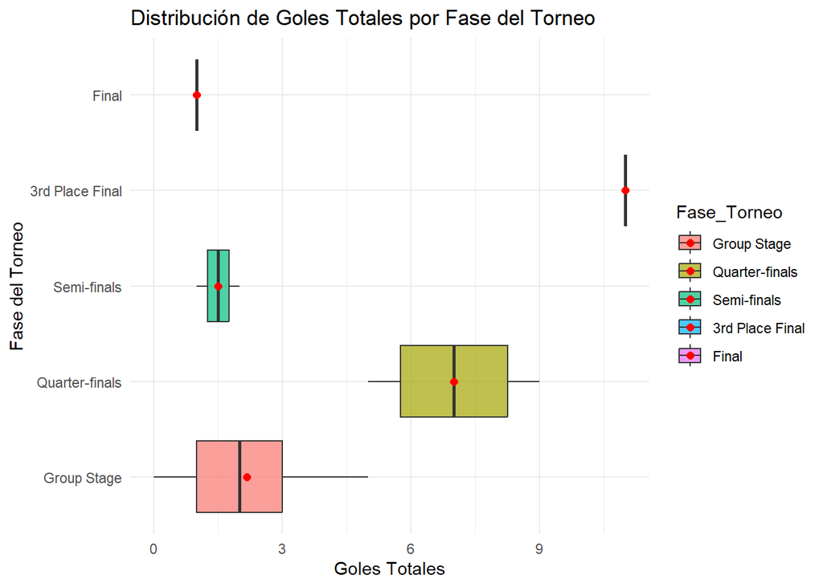

```r
# Cargar librerías necesarias
library(ggplot2)
library(dplyr)

# Definir el orden deseado de las fases del torneo
datos <- datos %>%
  mutate(Fase_Torneo = factor(Fase_Torneo,
                              levels = c("Group Stage","Quarter-finals","Semi-finals", "3rd Place Final","Final")))

# Gráfico de cajas ordenado
ggplot(datos, aes(x = Fase_Torneo, y = Goles_Totales, fill = Fase_Torneo)) +
  geom_boxplot(alpha = 0.7) +
  stat_summary(fun = mean, geom = "point", shape = 20, size = 3, color = "red") +
  labs(title = "Distribución de Goles Totales por Fase del Torneo",
       x = "Fase del Torneo",
       y = "Goles Totales") +
  theme_minimal() +
  coord_flip()  # Voltea el gráfico para mejor lectura
```